# Combine controls groups - Transcript

Jared J. Homola

4/18/2020

This analysis asks whether it is appropriate to combine the day 1 and day 14 control groups for the analysis that asks “How does expression differ among treatment groups?”. This is for the transcript-level data.

```r
## Load packages and data
library(limma)
library(edgeR)
library(Glimma)
library(gplots)
library(ggrepel)
library(RColorBrewer)
library(gridExtra)
library(kableExtra)
library(tidyverse)

setwd("G:/Shared drives/RNA Seq Supershedder Project/BWTE DE manuscript/bwteDE")

## Load data
annot <- read.delim("./extData/Trinotate.csv", header = TRUE, sep = "\t")
cnt <- read.table("./extData/rsem.isoform.counts.matrix", header = TRUE)
covars <- read.csv("./extData/BWTE54_SSgroup_Raw_Pool.csv", header = TRUE)
```

### Clean data

Bird 36 is missing a measurement for the weight covariate and bird 19 had improper tissue-based grouping, suggesting a potential sample mix up. They are both removed from the analysis. We also rename the genes, dropping the “Trinity_” prefix.

```r
cnt.bursa <- cnt %>%
  select(
    -alignEstimateAbundance_BWTE_Ileum_36_S50,
    -alignEstimateAbundance_BWTE_Bursa_36_S31,-alignEstimateAbundance_BWTE_Ileum_19_S35,
    -alignEstimateAbundance_BWTE_Bursa_19_S14) %>%
  rownames_to_column("transcript") %>%
  separate(transcript, into = c(NA, "pt1", "pt2", "gene", "isoform")) %>%
  unite(transcript, pt1, pt2, gene, isoform) %>%
  column_to_rownames("transcript") %>%
  select(contains("Bursa"))

cnt.ileum <- cnt %>%
  select(
    -alignEstimateAbundance_BWTE_Ileum_36_S50,
    -alignEstimateAbundance_BWTE_Bursa_36_S31,-alignEstimateAbundance_BWTE_Ileum_19_S35,
    -alignEstimateAbundance_BWTE_Bursa_19_S14) %>%
  rownames_to_column("transcript") %>%
  separate(transcript, into = c(NA, "pt1", "pt2", "gene", "isoform")) %>%
  unite(transcript, pt1, pt2, gene, isoform) %>%
  column_to_rownames("transcript") %>%
  select(contains("Ileum"))

covars <- covars %>%
  filter(!bird %in% c("36", "19")) %>%
  arrange(bird) %>%
  mutate(group = str_remove(group, "-"))

annot <- annot %>%
  separate(transcript_id, into = c(NA, "pt1", "pt2", "gene", "isoform")) %>%
  unite(transcript_id, pt1, pt2, gene, isoform)
```

### Set up model effects

```r
bird <- as.factor(covars$bird)
sex <- as.factor(covars$sex)
age <- as.numeric(covars$age)
weight <- covars$wt_55
group <- as.factor(covars$group)
pool.bursa <- as.factor(covars$Pool.Bursa)
pool.ileum <- as.factor(covars$Pool.Ileum)

covars.tib <- data.frame(bird,
                    sex,
                    age,
                    weight,
                    group,
                    pool.bursa,
                    pool.ileum) %>%
  as_tibble()
```

### Prep data for analysis

Here we standardize expression levels across samples of varying depth by using the counts per million (CPM) and trimmed mean of M-values (TMM) methods. We also remove any transcripts that are expressed at few than 0.5 CPM in at least 25% of individuals.

```r
#Convert to DGEList object
dge.bursa <- DGEList(counts=cnt.bursa)
dge.bursa$genes <- annot[match(rownames(dge.bursa$counts), annot$transcript_id),]

#CPM and log-CPM
cpm.bursa <- cpm(dge.bursa)
lcpm.bursa <- cpm(dge.bursa, log = TRUE)

#### Retain only transcripts expressed at >0.5 CPM in at least 25% of individuals
table(rowSums(dge.bursa$counts==0) == length(cnt.bursa[1,]))
```

```
##
##  FALSE   TRUE
## 475346  95759
```

```r
keep.exprs <- rowSums(cpm.bursa>0.5) >= length(cnt.bursa[1,])/4
sum(keep.exprs)
```

```
## [1] 74436
```

```r
dge.bursa <- dge.bursa[keep.exprs,, keep.lib.sizes=FALSE]
table(rowSums(dge.bursa$counts==0) == length(cnt.bursa[1,]))
```

```
##
## FALSE
## 74436
```

```r
dim(dge.bursa)
```

```
## [1] 74436    52
```

```r
#TMM normalization
dge.bursa <- calcNormFactors(dge.bursa, method = "TMM")

### Divide out controls
dge.bursa$samples$group <- covars.tib$group
dge.bursa.ctl <- dge.bursa[,grep('\\bC1\\b|\\bC14\\b', dge.bursa$samples$group)]
covars.bursa.ctl <- covars.tib %>% filter(group %in% c("C1", "C14")) %>% droplevels()


#Convert to DGEList object
dge.ileum <- DGEList(counts=cnt.ileum)
dge.ileum$genes <- annot[match(rownames(dge.ileum$counts), annot$transcript_id),]

#CPM and log-CPM
cpm.ileum <- cpm(dge.ileum)
lcpm.ileum <- cpm(dge.ileum, log = TRUE)

#### Retain only transcript expressed at >0.5 CPM in at least 25% of individuals
table(rowSums(dge.ileum$counts==0) == length(cnt.ileum[1,]))
```

```
##
##  FALSE   TRUE
## 484888  86217
```

```r
keep.exprs <- rowSums(cpm.ileum>0.5) >= length(cnt.ileum[1,])/4
sum(keep.exprs)
```

```
## [1] 66980
```

```r
dge.ileum <- dge.ileum[keep.exprs,, keep.lib.sizes=FALSE]
table(rowSums(dge.ileum$counts==0) == length(cnt.ileum[1,]))
```

```
##
## FALSE
## 66980
```

```r
dim(dge.ileum)
```

```
## [1] 66980    52
```

```r
#TMM normalization
dge.ileum <- calcNormFactors(dge.ileum, method = "TMM")

### Divide out controls
dge.ileum$samples$group <- covars.tib$group
dge.ileum.ctl <- dge.ileum[,grep('\\bC1\\b|\\bC14\\b', dge.ileum$samples$group)]
covars.ileum.ctl <- covars.tib %>% filter(group %in% c("C1", "C14")) %>% droplevels()
```

### Plot MDS

Multidimensional scaling (MDS) plots are an ordination technique that lets us examine sample clustering based on overall transcript expression levels.

```r
# Subset bursa and ileum controls
lcpm.bursa.ctl.C1 <- lcpm.bursa[,"C1" == covars$group]
lcpm.bursa.ctl.C14 <- lcpm.bursa[,"C14" == covars$group]
lcpm.bursa.ctl <- cbind(lcpm.bursa.ctl.C1, lcpm.bursa.ctl.C14)

lcpm.ileum.ctl.C1 <- lcpm.ileum[,"C1" == covars$group]
lcpm.ileum.ctl.C14 <- lcpm.ileum[,"C14" == covars$group]
lcpm.ileum.ctl <- cbind(lcpm.ileum.ctl.C1, lcpm.ileum.ctl.C14)

labels.MDS <- colnames(lcpm.bursa.ctl) %>%
  gsub("alignEstimateAbundance_BWTE_Bursa_", "", .) %>%
  as_tibble() %>%
  mutate(group = c(rep("C1", 4), rep("C14", 5))) %>%
  unite("label", value:group, sep = "_", remove = FALSE)
```

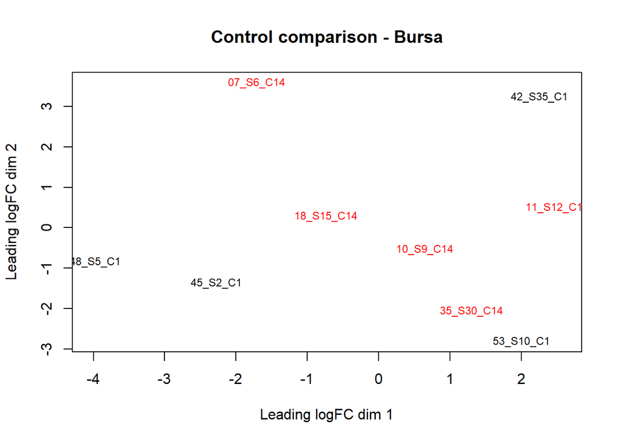

```r
col.group = as.numeric(as.factor(labels.MDS$group))
plotMDS(lcpm.bursa.ctl, labels = labels.MDS$label, col = col.group, cex = 0.75)
title(main="Control comparison - Bursa")
```

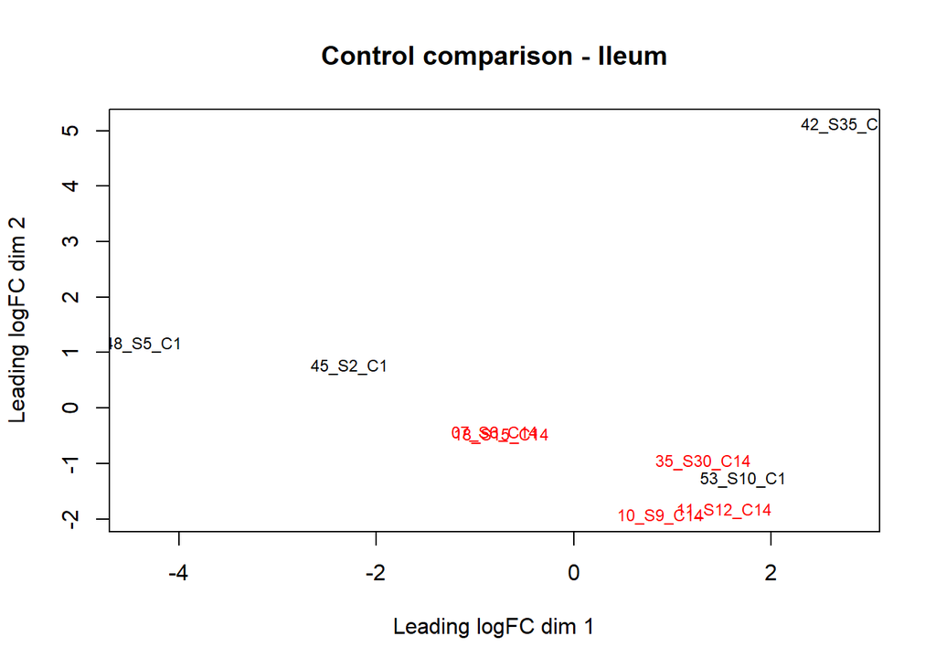

```r
col.group = as.numeric(as.factor(labels.MDS$group))
plotMDS(lcpm.ileum.ctl, labels = labels.MDS$label, col = col.group, cex = 0.75)
title(main="Control comparison - Ileum")
```

# Differential expression analysis

### Establish design & contrast matrices

```r
## Bursa
design.bursa = model.matrix(~ 0 +
                        covars.bursa.ctl$group +
                        covars.bursa.ctl$age +
                        covars.bursa.ctl$sex +
                        covars.bursa.ctl$weight +
                        covars.bursa.ctl$pool.bursa)

colnames(design.bursa) <- c("C1", "C14", "age", "sexM",
                         "weight", "pool2")

contr.matrix.bursa = makeContrasts(
  C1vC14 = C1 - C14,
  levels = colnames(design.bursa))

v.bursa <- voomWithQualityWeights(dge.bursa.ctl, design.bursa)

vfit.bursa <- lmFit(v.bursa, design.bursa)
vfit.bursa <- contrasts.fit(vfit.bursa, contrasts = contr.matrix.bursa)
tfit.bursa <- treat(vfit.bursa, lfc = 1.0)

## Ileum
design.ileum = model.matrix(~ 0 +
                        covars.ileum.ctl$group +
                        covars.ileum.ctl$age +
                        covars.ileum.ctl$sex +
                        covars.ileum.ctl$weight +
                        covars.ileum.ctl$pool.ileum)

colnames(design.ileum) <- c("C1", "C14", "age", "sexM",
                         "weight", "pool2")

contr.matrix.ileum = makeContrasts(
  C1vC14 = C1 - C14,
  levels = colnames(design.ileum))

v.ileum <- voomWithQualityWeights(dge.ileum.ctl, design.ileum)

vfit.ileum <- lmFit(v.ileum, design.ileum)
vfit.ileum <- contrasts.fit(vfit.ileum, contrasts = contr.matrix.ileum)
tfit.ileum <- treat(vfit.ileum, lfc = 1.0)
```

### Count DE transcripts

For a gene to be considered differentially expressed, we require a p-value of 0.1 with a false discovery rate correction and a log fold count difference of 1.

```r
dt.bursa <- decideTests(tfit.bursa, p.value = 0.1, adjust.method = "fdr")
summary(dt.bursa) %>%
  kable() %>%
  kable_styling(bootstrap_options = c("striped", "hover", "condensed", "responsive"), full_width = F)
```

|  | C1vC14 |
| --- | --- |
| Down | 0 |
| NotSig | 74436 |
| Up | 0 |

```r
dt.tib.bursa <- as_tibble(dt.bursa, rownames = NA) %>%
  rownames_to_column("transcript") %>%
  mutate_at(vars(starts_with("C")), as.numeric) %>%
  rename(C1vC14.bursa = C1vC14)

dt.ileum <- decideTests(tfit.ileum, p.value = 0.1, adjust.method = "fdr")
summary(dt.ileum) %>%
  kable() %>%
  kable_styling(bootstrap_options = c("striped", "hover", "condensed", "responsive"), full_width = F)
```

|  | C1vC14 |
| --- | --- |
| Down | 2 |
| NotSig | 66978 |
| Up | 0 |

```r
dt.tib <- as_tibble(dt.ileum, rownames = NA) %>%
  rownames_to_column("transcript") %>%
  mutate_at(vars(starts_with("C")), as.numeric) %>%
  rename(C1vC14.ileum = C1vC14) %>%
  left_join(dt.tib.bursa)
```

### Annotations for differentially expressed transcripts

```r
annot %>%
  select(
    transcript_id,
    sprot_Top_BLASTX_hit
  ) %>%
  rename(transcript = transcript_id) %>%
  inner_join(dt.tib) %>%
  separate(sprot_Top_BLASTX_hit, into = c("sprot1", NA, NA, NA, NA, "sprot2", NA), "\\^") %>%
  separate(sprot2, sep = "=", into = c(NA, "SwissProt_GeneFunction")) %>%
  separate(sprot1, sep = "_", into = c("SwissProt_GeneName", NA)) %>%
  mutate_at(.vars = vars(C1vC14.ileum:C1vC14.bursa),
            .funs = ~ ifelse(. == 1, "up", .)) %>%
  mutate_at(.vars = vars(C1vC14.ileum:C1vC14.bursa),
            .funs = ~ ifelse(. == -1, "down", .)) %>%
  filter_at(vars(C1vC14.ileum:C1vC14.bursa), any_vars(. != 0)) %>%
  distinct(transcript, .keep_all = TRUE) %>%
  select(-SwissProt_GeneFunction) %>%
  kable() %>%
  kable_styling(bootstrap_options = c("striped", "hover", "condensed", "responsive"))
```

| transcript | SwissProt_GeneName | C1vC14.ileum | C1vC14.bursa |
| --- | --- | --- | --- |
| DN5715_c0_g1_i5 | MXRA5 | down | 0 |
| DN1394_c1_g1_i3 | JUN | down | 0 |

#### Gene functions

```r
annot %>%
  select(
    transcript_id,
    sprot_Top_BLASTX_hit,
    Kegg
  ) %>%
  rename(transcript = transcript_id) %>%
  inner_join(dt.tib) %>%
  separate(sprot_Top_BLASTX_hit, into = c("sprot1", NA, NA, NA, NA, "sprot2", NA), "\\^") %>%
  separate(sprot2, sep = "=", into = c(NA, "SwissProt_GeneFunction")) %>%
  separate(sprot1, sep = "_", into = c("SwissProt_GeneName", NA)) %>%
  mutate_at(.vars = vars(C1vC14.ileum:C1vC14.bursa),
            .funs = ~ ifelse(. == 1, "up", .)) %>%
  mutate_at(.vars = vars(C1vC14.ileum:C1vC14.bursa),
            .funs = ~ ifelse(. == -1, "down", .)) %>%
  filter_at(vars(C1vC14.ileum:C1vC14.bursa), any_vars(. != 0)) %>%
  distinct(SwissProt_GeneName, .keep_all = TRUE) %>%
  select(SwissProt_GeneName, Kegg) %>%
  kable() %>%
  kable_styling(bootstrap_options = c("striped", "hover", "condensed", "responsive"))
```

| SwissProt_GeneName | Kegg |
| --- | --- |
| MXRA5 | KEGG:hsa:25878 |
| JUN | KEGG:gga:424673`KO:K04448 |